# 3. Linear Regression

Modeling the relationship between two variables

Author

Gustavo Roa

# Linear Regression

Correlation describes the strength and direction of an association between two variables.

**Linear regression** goes one step further by modeling how a response variable changes as a function of an explanatory variable.

In agricultural research, we may ask:

> **How does sulfur concentration in plant tissue change as nitrogen concentration changes?**

In this section, we will use **R1 sulfur concentration** as the response variable and **R1 nitrogen concentration** as the explanatory variable.

# The linear regression model

A simple linear regression model can be written as:

$$Y_i = \beta_0 + \beta_1X_i + \varepsilon_i$$

where:

- $Y_i$ is the response variable.
- $X_i$ is the explanatory variable.
- $\beta_0$ is the intercept.
- $\beta_1$ is the slope.
- $\varepsilon_i$ is the random error.

The expected value of $Y$ given $X$ is:

$$E(Y|X) = \beta_0 + \beta_1X$$

The fitted regression equation is:

$$\hat{Y} = b_0 + b_1X$$

where $b_0$ and $b_1$ are the estimated intercept and slope.

## Interpreting the coefficients

### Intercept

The **intercept** $(b_0)$ is the predicted value of $Y$ when $X=0$.

The biological interpretation of the intercept depends on whether $X=0$ is meaningful and within the range of the data.

### Slope

The **slope** $(b_1)$ represents the expected change in $Y$ for a one-unit increase in $X$.

For example, if:

$$b_1 = 0.05$$

a one-unit increase in $X$ is associated with an estimated 0.05-unit increase in $Y$.

The sign of the slope indicates the direction of the relationship:

- $b_1 > 0$: positive relationship.
- $b_1 < 0$: negative relationship.
- $b_1 = 0$: no linear relationship.

# Residuals

A **residual** is the difference between the observed and predicted value:

$$e_i = y_i - \hat{y}_i$$

Linear regression uses **ordinary least squares (OLS)** to estimate the coefficients by minimizing the sum of squared residuals:

$$\sum_{i=1}^{n}(y_i-\hat{y}_i)^2$$

In simple terms:

> **The regression line is the line that minimizes the total squared vertical distance between the observations and the fitted values.**

# Assumptions of linear regression

Before interpreting a linear regression, we should check whether the model assumptions are reasonable.

| Assumption | What to look for |
| --- | --- |
| **Linearity** | The relationship between $X$ and $Y$ is approximately linear. |
| **Independence** | Observations are independent. |
| **Constant variance** | Residual variability is reasonably similar across fitted values. |
| **Normal residuals** | Residuals are approximately normal for standard inference. |

These assumptions should be evaluated using the **study design, scatterplot, and diagnostic plots**.

# Load the required packages

We will use:

- `readxl` to import the Excel dataset.
- `ggplot2` to create graphs.
- `ggpmisc` to add the equation to the figure.

```r
# Import Excel files
library(readxl)

# Create graphs
library(ggplot2)

# Add equation to ggplot2
library(ggpmisc)
```

# Load the data

We will use the same agronomic dataset from the previous sections.

```r
# Import the workshop dataset
AllData <- read_excel(
  "Data_example.xlsx",
  sheet = "data"
)

# Check the structure of the dataset
str(AllData)
```

```
tibble [20 × 11] (S3: tbl_df/tbl/data.frame)
 $ year             : num [1:20] 2022 2022 2022 2022 2022 ...
 $ location         : chr [1:20] "Ashland" "Ashland" "Ashland" "Ashland" ...
 $ block            : num [1:20] 1 1 1 1 1 2 2 2 2 2 ...
 $ S_rate_kg_ha     : num [1:20] 34 11 45 22 0 0 34 22 11 45 ...
 $ grain_yield_Mg_ha: num [1:20] 9.04 10.66 11.25 10.06 7.75 ...
 $ biomass_V6_Mg_ha : num [1:20] 0.39 0.46 0.48 0.38 0.69 0.35 0.49 0.75 0.68 0.59 ...
 $ biomass_R1_Mg_ha : num [1:20] 7.82 8.52 7.6 7.47 10.3 ...
 $ S_conc_V6_pct    : num [1:20] 0.28 0.24 0.29 0.25 0.23 0.25 0.25 0.24 0.24 0.25 ...
 $ N_conc_V6_pct    : num [1:20] 3.86 3.65 3.78 3.67 3.74 3.93 3.8 3.68 3.87 3.66 ...
 $ S_conc_R1_pct    : num [1:20] 0.15 0.13 0.14 0.12 0.13 0.16 0.13 0.13 0.11 0.14 ...
 $ N_conc_R1_pct    : num [1:20] 1.7 1.57 1.7 1.38 1.59 1.81 1.62 1.6 1.41 1.63 ...
```

# Our example

We will examine the relationship between:

- **Response:** R1 sulfur concentration
- **Explanatory variable:** R1 nitrogen concentration

Our research question is:

> **Is R1 sulfur concentration linearly associated with R1 nitrogen concentration?**

# Explore the data

Before fitting a model, we should look at the relationship between the two variables.

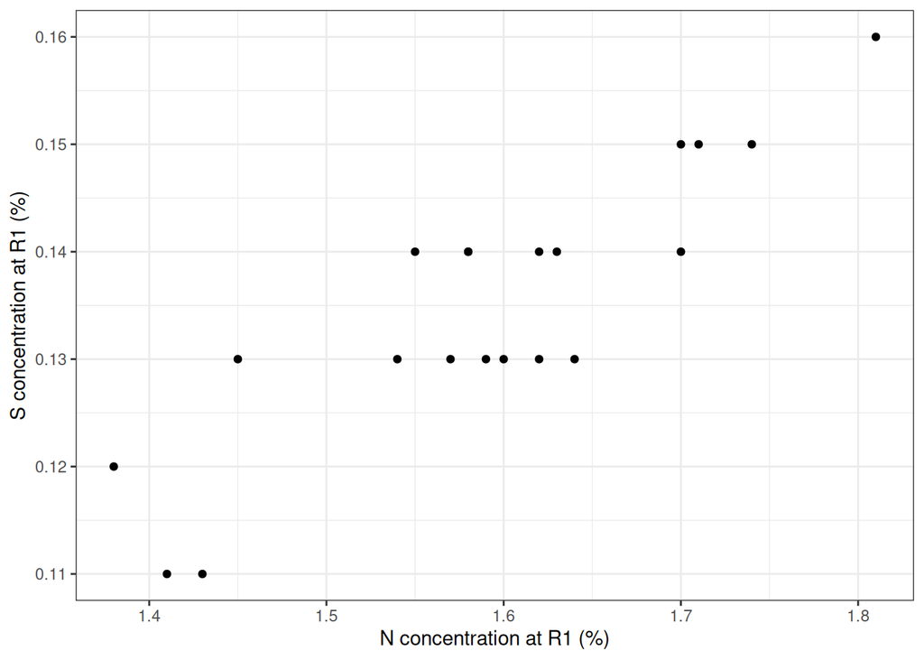

When looking at the scatterplot, ask:

- Does the relationship appear approximately linear?
- Is the relationship positive or negative?
- Are there unusual observations?

# Fit the linear regression model

We can fit a simple linear regression using `lm()`.

```r
# Fit the linear regression model
model <- lm(
  S_conc_R1_pct ~ N_conc_R1_pct,
  data = AllData
)

# Display the model summary
summary(model)
```

```
Call:
lm(formula = S_conc_R1_pct ~ N_conc_R1_pct, data = AllData)

Residuals:
       Min         1Q     Median         3Q        Max
-0.0097250 -0.0057065  0.0007988  0.0047645  0.0092276

Coefficients:
              Estimate Std. Error t value Pr(>|t|)
(Intercept)   -0.02341    0.02036  -1.150    0.265
N_conc_R1_pct  0.09947    0.01275   7.801  3.5e-07 ***
---
Signif. codes:  0 '***' 0.001 '**' 0.01 '*' 0.05 '.' 0.1 ' ' 1

Residual standard error: 0.00627 on 18 degrees of freedom
Multiple R-squared:  0.7717,    Adjusted R-squared:  0.759
F-statistic: 60.85 on 1 and 18 DF,  p-value: 3.504e-07
```

# Understanding the model summary

The `summary()` function provides information about the estimated coefficients and overall model fit.

| Output | Meaning |
| --- | --- |
| **Estimate** | Estimated intercept or slope |
| **Std. Error** | Uncertainty of the estimate |
| **t value** | Estimate divided by its standard error |
| **`Pr(>\|t\|)`** | P-value for testing whether the coefficient equals zero |
| **R-squared** | Proportion of variation in the response explained by the model |
| **Adjusted R-squared** | R-squared adjusted for the number of predictors |
| **Residual standard error** | Typical size of the residuals |
| **F-statistic** | Test of the overall regression model |

## The P-value

For the slope, the null hypothesis is:

$$H_0: \beta_1 = 0$$

The alternative hypothesis is:

$$H_A: \beta_1 \neq 0$$

A small P-value provides evidence that the slope differs from zero.

However:

> **The P-value does not tell us how large or biologically important the relationship is.**

The P-value should be interpreted together with the **slope, its uncertainty, and the data visualization**.

## R-squared

$R^2$ describes the proportion of variation in the response explained by the model.

For example:

$$R^2 = 0.70$$

means that the model explains approximately 70% of the observed variation in the response.

A high $R^2$ does not automatically mean that the model is appropriate or that the relationship is biologically important.

# Add the regression line

The fitted regression line shows the estimated linear relationship between R1 N and S concentrations.

The equation and $R^2$ are added to the figure to connect the visual relationship with the regression results.

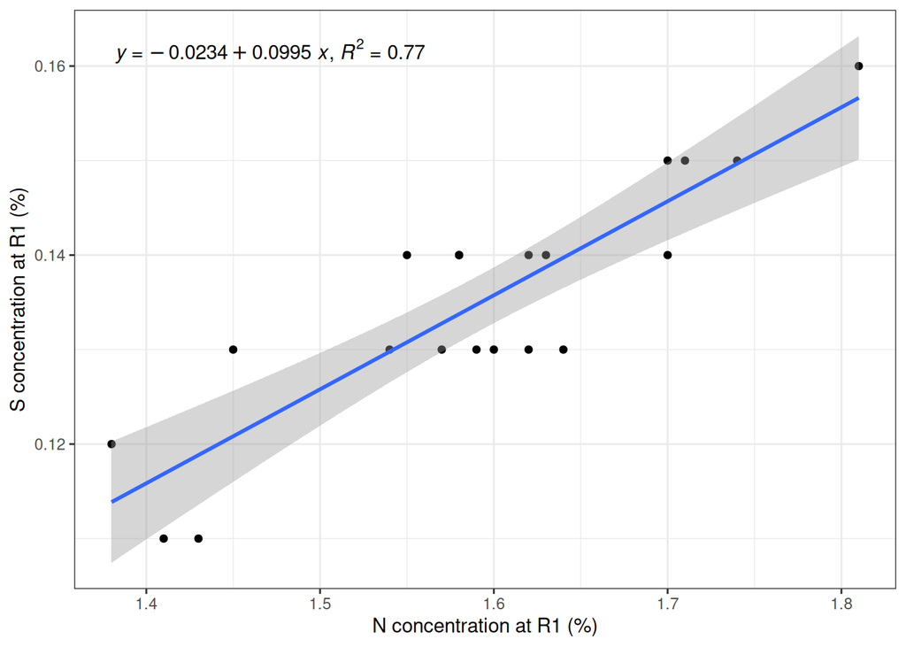

The equation represents the fitted model:

$$\hat{Y} = b_0 + b_1X$$

where $b_0$ is the estimated intercept and $b_1$ is the estimated slope.

The $R^2$ value describes the proportion of variation in the response explained by the linear regression model.

The shaded region around the regression line represents the **95% confidence interval for the estimated mean response**.

# Check the model assumptions

We can use diagnostic plots to look for potential problems.

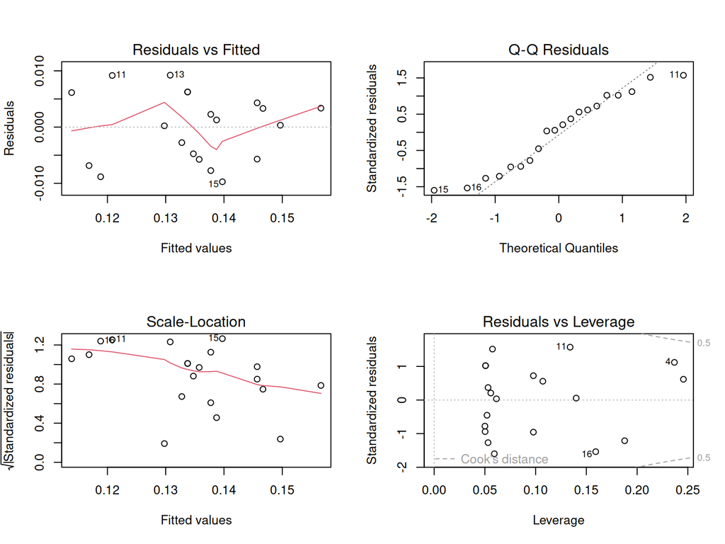

```r
# Create standard regression diagnostic plots
par(mfrow = c(2, 2))
plot(model)
```

Focus on three main questions:

1. Is there evidence of **nonlinearity**?
2. Is the **residual variance** reasonably constant?
3. Are there **unusual or influential observations**?

The Normal Q-Q plot can also help assess whether the residuals are approximately normal.

> Diagnostic plots help us determine whether the assumptions of the model are reasonable.

# Exercise

## Exercise 3.1: Fit the model

Fit a linear regression with:

- `S_conc_R1_pct` as the response.
- `N_conc_R1_pct` as the explanatory variable.

```r
# Fit the linear regression model
model_ex <- lm(
  ____________ ~ ____________,
  data = AllData
)

summary(model_ex)
```

**TipShow solution**

```r
# Fit the linear regression model
model_ex <- lm(
  S_conc_R1_pct ~ N_conc_R1_pct,
  data = AllData
)

summary(model_ex)
```

```
Call:
lm(formula = S_conc_R1_pct ~ N_conc_R1_pct, data = AllData)

Residuals:
       Min         1Q     Median         3Q        Max
-0.0097250 -0.0057065  0.0007988  0.0047645  0.0092276

Coefficients:
              Estimate Std. Error t value Pr(>|t|)
(Intercept)   -0.02341    0.02036  -1.150    0.265
N_conc_R1_pct  0.09947    0.01275   7.801  3.5e-07 ***
---
Signif. codes:  0 '***' 0.001 '**' 0.01 '*' 0.05 '.' 0.1 ' ' 1

Residual standard error: 0.00627 on 18 degrees of freedom
Multiple R-squared:  0.7717,    Adjusted R-squared:  0.759
F-statistic: 60.85 on 1 and 18 DF,  p-value: 3.504e-07
```

## Exercise 3.2: Create the regression plot

Create a scatterplot showing the relationship between R1 N and S concentrations.

Your figure should include:

- The observed data points.
- The fitted linear regression line.
- The 95% confidence interval.
- The fitted regression equation.
- $R^2$.
- Descriptive axis labels with units.

Try it yourself:

```r
# Create a scatterplot and add the fitted regression model
ggplot(
  AllData,
  aes(
    x = ____________,
    y = ____________
  )
) +
  geom_point() +
  geom_smooth(
    method = "lm",
    se = TRUE
  ) +
  stat_poly_eq(
    aes(
      label = paste(
        after_stat(eq.label),
        after_stat(rr.label),
        sep = "*\", \"*"
      )
    ),
    formula = y ~ x,
    coef.digits = 3,
    rr.digits = 2,
    parse = TRUE,
    size = 5
  ) +
  labs(
    x = "____________",
    y = "____________"
  ) +
  theme_bw()
```

**TipShow solution**

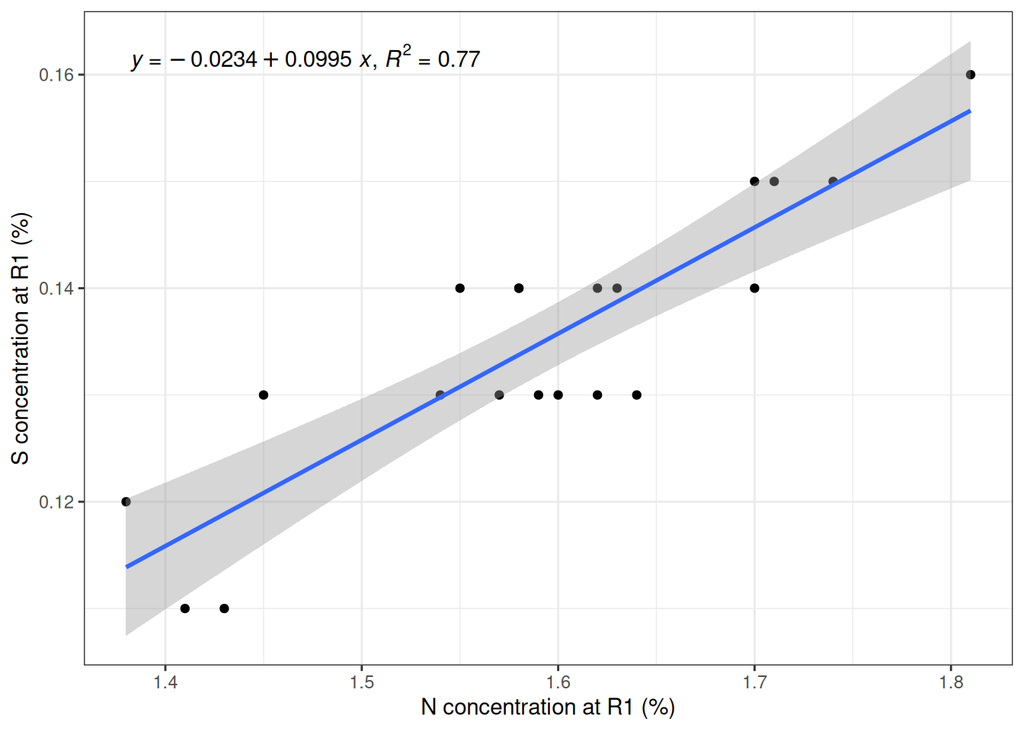

```r
# Create a scatterplot of R1 N and S concentrations
ggplot(
  AllData,
  aes(
    x = N_conc_R1_pct,
    y = S_conc_R1_pct
  )
) +

  # Add observed data points
  geom_point() +

  # Add the fitted regression line and 95% CI
  geom_smooth(
    method = "lm",
    se = TRUE
  ) +

  # Add the regression equation and R-squared
  stat_poly_eq(
    aes(
      label = paste(
        after_stat(eq.label),
        after_stat(rr.label),
        sep = "*\", \"*"
      )
    ),
    formula = y ~ x,
    coef.digits = 3,
    rr.digits = 2,
    parse = TRUE
  ) +

  # Add descriptive axis labels
  labs(
    x = "N concentration at R1 (%)",
    y = "S concentration at R1 (%)"
  ) +

  # Use a simple theme
  theme_bw()
```

## Exercise 3.3: Interpret the results

Use the model output and graph to answer:

1. What is the estimated slope?
2. Is the relationship positive or negative?
3. What does the slope mean in this context?
4. What is the P-value for the slope?
5. What is the $R^2$?

# Key takeaways

- Linear regression models the relationship between a response and an explanatory variable.
- The **slope** describes the expected change in the response for a one-unit increase in the explanatory variable.
- The **P-value** evaluates evidence against a zero slope.
- $R^2$ describes the proportion of response variation explained by the model.
- Model assumptions should be checked using the data and diagnostic plots.
- Statistical significance does not necessarily indicate biological importance.

> **Interpret the coefficient, evaluate its uncertainty, and check whether the model is reasonable.**

# Next section

In the next section, we will use **analysis of variance (ANOVA)** to compare responses among multiple groups.